# Lab 8: Cannabis Types

Author

Samuel Lonac

```python
import pandas as pd
import numpy as np
import matplotlib.pyplot as plt
from sklearn.pipeline import Pipeline
from sklearn.neighbors import KNeighborsClassifier
from sklearn.tree import DecisionTreeClassifier
from sklearn.linear_model import LogisticRegression
from sklearn.compose import make_column_selector, ColumnTransformer
from sklearn.discriminant_analysis import LinearDiscriminantAnalysis, QuadraticDiscriminantAnalysis
from sklearn.svm import SVC
from sklearn.preprocessing import StandardScaler, OneHotEncoder
from sklearn.model_selection import GridSearchCV, cross_val_score, cross_val_predict
from sklearn.tree import DecisionTreeClassifier, plot_tree
from sklearn.metrics import get_scorer_names, confusion_matrix
from sklearn.impute import SimpleImputer
```

```python
weed = pd.read_csv("cannabis_full.csv")
```

# Part One: Binary Classification

```python
sat_or_ind = weed[(weed['Type'] == 'sativa')| (weed['Type'] == 'indica')]
```

```python
#convert 'Type' into binary categorical variable
type_mapping = {'sativa': 0, 'indica': 1}
sat_or_ind['Type_binary'] = sat_or_ind['Type'].map(type_mapping)
```

```
SettingWithCopyWarning:
A value is trying to be set on a copy of a slice from a DataFrame.
Try using .loc[row_indexer,col_indexer] = value instead

See the caveats in the documentation: https://pandas.pydata.org/pandas-docs/stable/user_guide/indexing.html#returning-a-view-versus-a-copy
  sat_or_ind['Type_binary'] = sat_or_ind['Type'].map(type_mapping)
```

```python
sat_or_ind_cleaned = sat_or_ind.dropna()
```

```python
X = sat_or_ind_cleaned.drop(['Strain', 'Type', 'Type_binary', 'Effects', 'Flavor'], axis = 1)
y = sat_or_ind_cleaned['Type_binary']
```

```python
ct = ColumnTransformer(
  [
    ("standardize",
    StandardScaler(),
     ['Rating'])
  ],
  remainder = "passthrough")
```

For all models, the scoring metric of f1_macro was chosen as it balances precision and recall and averages them across all classes. This is important when there is no target category because going for a balanced metric will insure that there is no preference to one target category.

## Q1: LDA

```python
pipeline_lda = Pipeline([
    ('preprocessing', ct),
    ('classifier', LinearDiscriminantAnalysis())
])

param_grid_lda = {
    'classifier__solver': ['svd', 'lsqr']
}

grid_search_lda = GridSearchCV(pipeline_lda, param_grid_lda, cv=5, scoring = 'f1_macro')

fitted_pipeline_lda = grid_search_lda.fit(X, y)

#get best estimator and params
best_lda = fitted_pipeline_lda.best_estimator_.named_steps['classifier']
best_params_lda = fitted_pipeline_lda.best_params_
best_score_lda = fitted_pipeline_lda.best_score_

#get coefficients and intercept
coefs_lda = best_lda.coef_[0]
intercept_lda = best_lda.intercept_[0]

#make predictions for confusion matrix
y_preds_lda = cross_val_predict(best_lda, X, y, cv=5)

conf_matrix_lda = confusion_matrix(y, y_preds_lda)

best_params_lda, best_score_lda, conf_matrix_lda
```

```
({'classifier__solver': 'svd'},
 0.8299685165213692,
 array([[319, 112],
        [ 64, 623]]))
```

## Q2: QDA

```python
pipeline_qda = Pipeline([
    ('preprocessing', ct),
    ('classifier', QuadraticDiscriminantAnalysis())
])

param_grid_qda = {
    'classifier__reg_param': [0.0, 0.2, 0.4, 0.6, 0.8, 1.0]
}

grid_search_qda = GridSearchCV(pipeline_qda, param_grid_qda, cv=5, scoring = 'f1_macro')

fitted_pipeline_qda = grid_search_qda.fit(X, y)

#get best estimator and params
best_qda = fitted_pipeline_qda.best_estimator_.named_steps['classifier']
best_params_qda = fitted_pipeline_qda.best_params_
best_score_qda = fitted_pipeline_qda.best_score_

#make predictions for confusion matrix
y_preds_qda = cross_val_predict(best_qda, X, y, cv=5)

conf_matrix_qda = confusion_matrix(y, y_preds_qda)

best_params_qda, best_score_qda, conf_matrix_qda
```

[output not shown]

[output cut: 17 more lines]

[output not shown]

```
({'classifier__reg_param': 0.2},
 0.8365122875136667,
 array([[334,  97],
        [ 72, 615]]))
```

## Q3: SVC

```python
pipeline_svc = Pipeline([
    ('preprocessing', ct),
    ('classifier', SVC(kernel = 'linear'))
])

param_grid_svc = {
    'classifier__C': [0.1, 1, 10],
    'classifier__gamma': ['scale', 'auto']
}

grid_search_svc = GridSearchCV(pipeline_svc, param_grid_svc, cv=5, scoring='f1_macro')
fitted_pipeline_svc = grid_search_svc.fit(X, y)

#get best estimator and params
best_svc = fitted_pipeline_svc.best_estimator_.named_steps['classifier']
best_params_svc = fitted_pipeline_svc.best_params_
best_score_svc = fitted_pipeline_svc.best_score_

#make predictions for confusion matrix
y_preds_svc = cross_val_predict(best_svc, X, y, cv=5)

conf_matrix_svc = confusion_matrix(y, y_preds_svc)

best_params_svc, best_score_svc, conf_matrix_svc
```

```
({'classifier__C': 0.1, 'classifier__gamma': 'scale'},
 0.8400849513852038,
 array([[323, 108],
        [ 57, 630]]))
```

## Q4: SVM

```python
pipeline_svm = Pipeline([
    ('preprocessing', ct),
    ('classifier', SVC(kernel = 'poly'))
])

param_grid_svm = {
    'classifier__C': [0.1, 1, 10],
    'classifier__degree': [2, 3, 4],
    'classifier__gamma': ['scale', 'auto']
}

grid_search_svm = GridSearchCV(pipeline_svm, param_grid_svc, cv=5, scoring='f1_macro')
fitted_pipeline_svm = grid_search_svm.fit(X, y)

#get best estimator and params
best_svm = fitted_pipeline_svm.best_estimator_.named_steps['classifier']
best_params_svm = fitted_pipeline_svm.best_params_
best_score_svm = fitted_pipeline_svm.best_score_

#make predictions for confusion matrix
y_preds_svm = cross_val_predict(best_svm, X, y, cv=5)

conf_matrix_svm = confusion_matrix(y, y_preds_svm)

best_params_svm, best_score_svm, conf_matrix_svm
```

```
({'classifier__C': 1, 'classifier__gamma': 'scale'},
 0.8411153895369242,
 array([[322, 109],
        [ 58, 629]]))
```

# Part Two: Natural Multiclass

```python
weed_cleaned = weed.dropna()
```

```python
weed_cleaned['Type'] = weed_cleaned['Type'].astype('category')
```

```
SettingWithCopyWarning:
A value is trying to be set on a copy of a slice from a DataFrame.
Try using .loc[row_indexer,col_indexer] = value instead

See the caveats in the documentation: https://pandas.pydata.org/pandas-docs/stable/user_guide/indexing.html#returning-a-view-versus-a-copy
  weed_cleaned['Type'] = weed_cleaned['Type'].astype('category')
```

```python
#convert 'Type' into a categorical variable
type_mapping = {'sativa': 0, 'indica': 1, 'hybrid': 2}
weed_cleaned['Type_encoded'] = weed_cleaned['Type'].map(type_mapping)
```

```
SettingWithCopyWarning:
A value is trying to be set on a copy of a slice from a DataFrame.
Try using .loc[row_indexer,col_indexer] = value instead

See the caveats in the documentation: https://pandas.pydata.org/pandas-docs/stable/user_guide/indexing.html#returning-a-view-versus-a-copy
  weed_cleaned['Type_encoded'] = weed_cleaned['Type'].map(type_mapping)
```

```python
X = weed_cleaned.drop(['Strain', 'Type', 'Type_encoded', 'Effects', 'Flavor'], axis = 1)
y = weed_cleaned['Type_encoded']
```

## Q1: Decision Tree

```python
pipeline_d_tree = Pipeline([
    ('preprocessing', ct),
    ('classifier', DecisionTreeClassifier(random_state=0))
])

param_grid_d_tree = {
    'classifier__min_impurity_decrease' : [.001, .05, .1, .25, .5, .75, 1]
}

grid_search_d_tree = GridSearchCV(pipeline_d_tree, param_grid_d_tree, cv=5, scoring='f1_macro')
fitted_pipeline_d_tree = grid_search_d_tree.fit(X, y)

#get best estimator and its parameters
best_d_tree = fitted_pipeline_d_tree.best_estimator_.named_steps['classifier']
best_params_decision_tree = grid_search_d_tree.best_params_
best_score_decision_tree = grid_search_d_tree.best_score_

best_params_decision_tree, best_score_decision_tree
```

```
({'classifier__min_impurity_decrease': 0.001}, 0.5627612360726315)
```

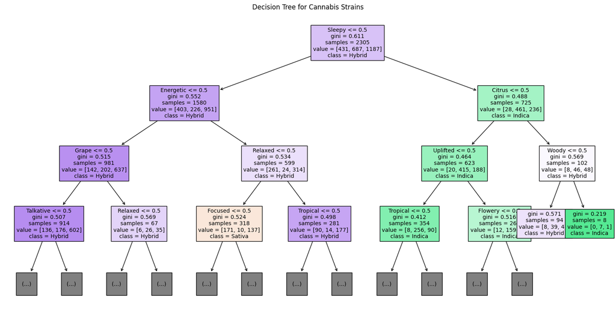

```python
#plot best decision tree
plt.figure(figsize=(20,10))
plot_tree(best_d_tree,
          filled=True,
          feature_names=X.columns,
          class_names=['Sativa', 'Indica', 'Hybrid'],
          max_depth=3,
          fontsize=10)
plt.title("Decision Tree for Cannabis Strains")
plt.show()
```

## Q2: LDA, QDA and KNN

### LDA

```python
pipeline_lda_full = Pipeline([
    ('preprocessing', ct),
    ('classifier', LinearDiscriminantAnalysis())
])
param_grid_lda_full = {'classifier__solver': ['svd', 'lsqr']}
grid_search_lda_full = GridSearchCV(pipeline_lda_full, param_grid_lda_full, cv=5, scoring='f1_macro')

fitted_pipeline_lda_full = grid_search_lda_full.fit(X, y)

#extracting best parameters, score, and confusion matrix for LDA
best_lda_full = fitted_pipeline_lda_full.best_estimator_.named_steps['classifier']
best_params_lda_full = fitted_pipeline_lda_full.best_params_
best_score_lda_full = fitted_pipeline_lda_full.best_score_
y_preds_lda_full = cross_val_predict(best_lda_full, X, y, cv=5)
conf_matrix_lda_full = confusion_matrix(y, y_preds_lda_full)

best_params_lda_full, best_score_lda_full, conf_matrix_lda_full
```

```
({'classifier__solver': 'svd'},
 0.5939249916749908,
 array([[178,  23, 230],
        [ 12, 455, 220],
        [146, 224, 817]]))
```

### QDA

```python
pipeline_qda_full = Pipeline([
    ('preprocessing', ct),
    ('classifier', QuadraticDiscriminantAnalysis())
])
param_grid_qda_full = {'classifier__reg_param': [0.0, 0.2, 0.4, 0.6, 0.8, 1.0]}
grid_search_qda_full = GridSearchCV(pipeline_qda_full, param_grid_qda_full, cv=5, scoring='f1_macro')

fitted_pipeline_qda_full = grid_search_qda_full.fit(X, y)

#extracting best parameters, score, and confusion matrix for QDA
best_qda_full = fitted_pipeline_qda_full.best_estimator_.named_steps['classifier']
best_params_qda_full = fitted_pipeline_qda_full.best_params_
best_score_qda_full = fitted_pipeline_qda_full.best_score_
y_preds_qda_full = cross_val_predict(best_qda_full, X, y, cv=5)
conf_matrix_qda_full = confusion_matrix(y, y_preds_qda_full)

best_params_qda_full, best_score_qda_full, conf_matrix_qda_full
```

[output not shown]

[output cut: 17 more lines]

[output not shown]

```
({'classifier__reg_param': 0.2},
 0.5693717263381127,
 array([[139,  26, 266],
        [  5, 487, 195],
        [116, 283, 788]]))
```

### KNN

```python
pipeline_knn_full = Pipeline([
    ('preprocessing', ct),
    ('classifier', KNeighborsClassifier())
])
param_grid_knn_full = {'classifier__n_neighbors': [5, 10, 15], 'classifier__weights': ['uniform', 'distance']}
grid_search_knn_full = GridSearchCV(pipeline_knn_full, param_grid_knn_full, cv=5, scoring='f1_macro')

fitted_pipeline_knn_full = grid_search_knn_full.fit(X, y)

#extracting best parameters, score, and confusion matrix for KNN
best_knn_full = fitted_pipeline_knn_full.best_estimator_.named_steps['classifier']
best_params_knn_full = fitted_pipeline_knn_full.best_params_
best_score_knn_full = fitted_pipeline_knn_full.best_score_
y_preds_knn_full = cross_val_predict(best_knn_full, X, y, cv=5)
conf_matrix_knn_full = confusion_matrix(y, y_preds_knn_full)

best_params_knn_full, best_score_knn_full, conf_matrix_knn_full
```

```
({'classifier__n_neighbors': 10, 'classifier__weights': 'uniform'},
 0.5525237964367306,
 array([[157,  28, 246],
        [  7, 409, 271],
        [137, 260, 790]]))
```

## Q3: Were the Metrics Better or Worse than Part One?

Overall, the fl_macro scores from the Binary Classification models were much higher than the Natural Multiclass models. This makes intuitive sense, as Binary Classification is much simpler and only involves two categories of “Indica” vs. “Sativa” which have significant differences between them. Introducing a new classification of “Hybrid”, which is a mix of both other classifications and carries traits from both, makes it extremely difficult to sift out the Hybrids from the Indica and Sativa strains. Unsurpringly, the confusion matrices show the multiclass models struggling primarily with classifying the Hybrid strains, due to many of the Indica and Sativa strains being misclassified as Hybrid.

# Part Three: Multiclass from Binary

## Q1: OvR

```python
def fit_evaluate_ovr_models_svc_lr(X, y):

    """
    Fits and evaluates OvR models using SVC and Logistic Regression.

    Parameters:
    X: Features dataset (DataFrame or numpy array)
    y: Target labels (Series, array, or list)

    Functionality:
    - Sets up pipelines for SVC and Logistic Regression with preprocessing.
    - Performs 5-fold cross-validation using f1_macro score.
    - Fits models to the entire dataset.

    Returns:
    - Average F1 macro scores for SVC and Logistic Regression.
    """
    #setting up pipelines for SVC and Logistic Regression
    pipeline_svc = Pipeline([
        ('preprocessing', ct),
        ('classifier', SVC())
    ])
    pipeline_lr = Pipeline([
        ('preprocessing', ct),
        ('classifier', LogisticRegression())
    ])

    #performing cross-validation for SVC
    f1_svc = cross_val_score(pipeline_svc, X, y, cv=5, scoring='f1_macro').mean()
    pipeline_svc.fit(X, y)  # Fitting SVC model

    #performing cross-validation for Logistic Regression
    f1_lr = cross_val_score(pipeline_lr, X, y, cv=5, scoring='f1_macro').mean()
    pipeline_lr.fit(X, y)  # Fitting Logistic Regression model

    return f1_svc, f1_lr

#creating the binary target variable for "Indica vs. Not Indica"
weed_cleaned['Indica_binary'] = (weed_cleaned['Type'] == 'indica').astype(int)
y_indica = weed_cleaned['Indica_binary']

#"Indica vs. Not Indica"
f1_svc_indica, f1_lr_indica = fit_evaluate_ovr_models_svc_lr(X, y_indica)

#creating the binary target variable for "Sativa vs. Not Sativa"
weed_cleaned['Sativa_binary'] = (weed_cleaned['Type'] == 'sativa').astype(int)
y_sativa = weed_cleaned['Sativa_binary']

#"Sativa vs. Not Sativa"
f1_svc_sativa, f1_lr_sativa = fit_evaluate_ovr_models_svc_lr(X, y_sativa)

#creating the binary target variable for "Hybrid vs. Not Hybrid"
weed_cleaned['Hybrid_binary'] = (weed_cleaned['Type'] == 'hybrid').astype(int)
y_hybrid = weed_cleaned['Hybrid_binary']

#"Hybrid vs. Not Hybrid"
f1_svc_hybrid, f1_lr_hybrid = fit_evaluate_ovr_models_svc_lr(X, y_hybrid)

f1_svc_indica, f1_lr_indica, f1_svc_sativa, f1_lr_sativa, f1_svc_hybrid, f1_lr_hybrid
```

[output not shown]

```
(0.7443399814664896,
 0.7464307015675271,
 0.6155624435914452,
 0.6458088347148756,
 0.6286594869123139,
 0.6146536090721264)
```

## Q2: Which of the six models did the best, and which did the worst?

The model that performed best at distinguishing the target category from the rest of the data was the logistic regression on Indica vs. Not Indica. The model that did the worst was the logistic regression on Hybrid vs. Not Hybrid. This makes intuitive sense, since Indica vs. Not Indica has clearer traits, while Hybrids share a lot of traits with both Indica and Sativa and therefore are harder to classify.

## Q3: OvO

```python
def create_ovo_labels(df, class1, class2):

    """
    Creates binary labels for One-vs-One (OvO) classification tasks.

    Parameters:
    - df (DataFrame): The dataset containing a 'Type' column for classification.
    - class1 (str): The name of the first class in the OvO comparison.
    - class2 (str): The name of the second class in the OvO comparison.

    Returns:
    - A tuple of (binary_labels, filtered_df):
      - binary_labels (Series): Binary labels for class1 (1 for class1, 0 for class2).
      - filtered_df (DataFrame): The subset of the original DataFrame, including only rows where 'Type' is class1 or class2.
    """
    relevant_types = [class1, class2]
    df_filtered = df[df['Type'].isin(relevant_types)]
    return (df_filtered['Type'] == class1).astype(int), df_filtered

#creating binary labels for each OvO classification
y_indica_sativa, df_indica_sativa = create_ovo_labels(weed_cleaned, 'indica', 'sativa')
y_indica_hybrid, df_indica_hybrid = create_ovo_labels(weed_cleaned, 'indica', 'hybrid')
y_hybrid_sativa, df_hybrid_sativa = create_ovo_labels(weed_cleaned, 'hybrid', 'sativa')

# Function to fit and evaluate OvO models for SVC and Logistic Regression
def fit_evaluate_ovo_models_svc_lr(X, y):

    """
    Fits and evaluates One-vs-One (OvO) models using SVC and Logistic Regression.

    Parameters:
    - X (DataFrame or numpy array): The input features for the model.
    - y (Series, numpy array, or list): The target labels for classification.

    Functionality:
    - Creates pipelines for SVC and Logistic Regression, each with preprocessing and the classifier.
    - Performs 5-fold cross-validation for both models using the f1_macro scoring metric.
    - Fits both models to the entire dataset (X, y).

    Returns:
    - A tuple containing the average F1 macro scores for SVC and Logistic Regression models.
    """
    # Setting up pipelines for SVC and Logistic Regression
    pipeline_svc = Pipeline([
        ('preprocessing', ct),
        ('classifier', SVC())
    ])
    pipeline_lr = Pipeline([
        ('preprocessing', ct),
        ('classifier', LogisticRegression())
    ])

    # Performing cross-validation for SVC
    f1_svc = cross_val_score(pipeline_svc, X, y, cv=5, scoring='f1_macro').mean()
    pipeline_svc.fit(X, y)  # Fitting SVC model

    # Performing cross-validation for Logistic Regression
    f1_lr = cross_val_score(pipeline_lr, X, y, cv=5, scoring='f1_macro').mean()
    pipeline_lr.fit(X, y)  # Fitting Logistic Regression model

    return f1_svc, f1_lr

# Features for the models
X_indica_sativa = df_indica_sativa.drop(['Strain', 'Type', 'Type_encoded', 'Effects', 'Flavor',
                                         'Indica_binary', 'Sativa_binary', 'Hybrid_binary'], axis=1)
X_indica_hybrid = df_indica_hybrid.drop(['Strain', 'Type', 'Type_encoded', 'Effects', 'Flavor',
                                         'Indica_binary', 'Sativa_binary', 'Hybrid_binary'], axis=1)
X_hybrid_sativa = df_hybrid_sativa.drop(['Strain', 'Type', 'Type_encoded', 'Effects', 'Flavor',
                                         'Indica_binary', 'Sativa_binary', 'Hybrid_binary'], axis=1)

# Fitting and evaluating models
f1_svc_indica_sativa, f1_lr_indica_sativa = fit_evaluate_ovo_models_svc_lr(X_indica_sativa, y_indica_sativa)
f1_svc_indica_hybrid, f1_lr_indica_hybrid = fit_evaluate_ovo_models_svc_lr(X_indica_hybrid, y_indica_hybrid)
f1_svc_hybrid_sativa, f1_lr_hybrid_sativa = fit_evaluate_ovo_models_svc_lr(X_hybrid_sativa, y_hybrid_sativa)

f1_svc_indica_sativa, f1_lr_indica_sativa, f1_svc_indica_hybrid, f1_lr_indica_hybrid, f1_svc_hybrid_sativa, f1_lr_hybrid_sativa
```

```
(0.8457779788791502,
 0.8353581145277355,
 0.7329341127800424,
 0.7292482813727268,
 0.6098009516959261,
 0.6217984729553228)
```

## Q4: Which of the six models did the best, and which did the worst?

The model that performed best was the Support Vector Classifier on Indica vs. Sativa, while the worst model was the Support Vector Classifier on Hybrid vs. Sativa. This also makes intuitive sense, since we learned from the binary vs multiclass sections that finding the difference between Sativa and Indica is easier than determining the difference between Hybrid and either Sativa or Indica. The overlap in traits makes it much more difficult to distinguish in any model.

## Q5: LogisticRegression and SVC ‘OvO’ vs. ‘OvR’ Default Approach

If I were to input my data into sklearn’s LogisticRegression function, by default it would take into account the dataset and adjust the approach accordingly. This is because by default, the multi_class attribute is set to ‘auto’, which decides between ‘ovr’ and ‘multinomial’ based on the data input into the function as well as the solver chosen. Since the data from this activity had three classes, LogisticRegression would automatically switch to a ‘multinomial’ approach, which is different from OvO and OvR.

For SVC, on the other hand, OvO is the default. SVC’s documentation states that SVC is based on libsvm, and that “The multiclass support is handled according to a one-vs-one scheme”. Unlike LogisticRegression, there is not a specific parameter that auto detects based off of the data input.

# Citations:

- https://towardsdatascience.com/micro-macro-weighted-averages-of-f1-score-clearly-explained-b603420b292f
- https://scikit-learn.org/stable/modules/generated/sklearn.tree.plot_tree.html
- https://scikit-learn.org/stable/modules/generated/sklearn.svm.SVC.html
- https://scikit-learn.org/stable/modules/generated/sklearn.linear_model.LogisticRegression.html

Assisted by ChatGPT for: - ‘Type’ Variable mapping - Writing custom functions and function documentation